# Tugas Pertemuan 2 - Regresi

G1401231097 Zanira Husna

# Pemanggilan *Packages*

```r
install.packages("https://cran.r-project.org/src/contrib/Archive/orcutt/orcutt_2.1.tar.gz", repos = NULL, type = "source")
#install.packages("orcutt")
#install.packages("HoRM")
```

```r
library(dplyr)
library(TTR)
library(forecast)
library(lmtest) #digunakan untuk uji formal pendeteksian autokorelasi
library(orcutt) #untuk membuat model regresi Cochrane-Orcutt
library(HoRM) #untuk membuat model regresi Hildreth-Lu
```

# Input Data

Data yang digunakan adalah data IPM Kota Depok periode tahun 2010-2024.

```r
library(readxl)
data <- read_xlsx("C:\\Users\\ZANIRA\\Downloads\\[Metode Baru] Indeks Pembangunan Manusia, 2024.xlsx")
str(data)
```

```
## tibble [15 × 2] (S3: tbl_df/tbl/data.frame)
##  $ Tahun: num [1:15] 2010 2011 2012 2013 2014 ...
##  $ IPM  : num [1:15] 76.7 77 77.3 78.3 78.6 ...
```

# Eksplorasi Data

Sebelum melakukan regresi, akan diperlihatkan *plot time-series* dari IPM Kota Depok Periode 2010-2024

```r
#Membentuk objek time series
data.ts<-ts(data$IPM)
data.ts
```

```
## Time Series:
## Start = 1
## End = 15
## Frequency = 1
##  [1] 76.66 76.96 77.28 78.27 78.58 79.11 79.60 79.83 80.29 80.82 80.97 81.37
## [13] 81.86 82.38 82.91
```

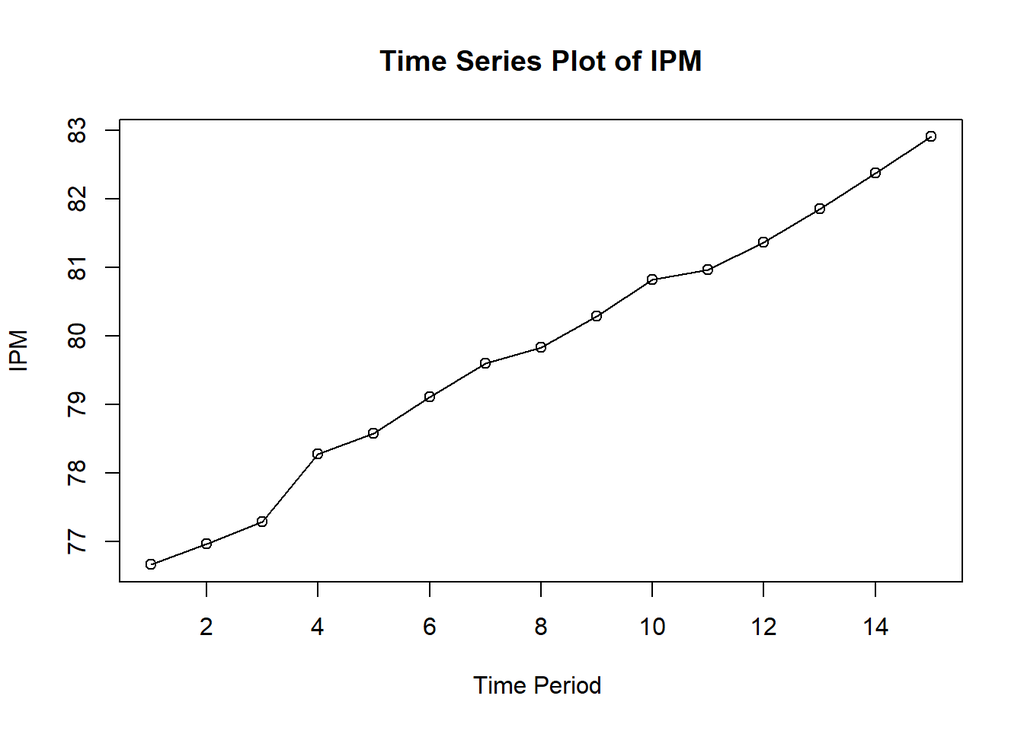

```r
#Membuat plot time series
ts.plot(data.ts, xlab="Time Period ", ylab="IPM", main= "Time Series Plot of IPM")
points(data.ts)
```

terlihat pada plot di atas menunjukkan adanya *trend*.

# Pemodelan regresi

```r
modelipm <- lm(IPM ~ Tahun, data = data)
summary(modelipm)
```

```
##
## Call:
## lm(formula = IPM ~ Tahun, data = data)
##
## Residuals:
##      Min       1Q   Median       3Q      Max
## -0.31892 -0.13267  0.03733  0.12671  0.24608
##
## Coefficients:
##               Estimate Std. Error t value Pr(>|t|)
## (Intercept) -805.16608   21.32962  -37.75 1.13e-14 ***
## Tahun          0.43875    0.01057   41.49 3.34e-15 ***
## ---
## Signif. codes:  0 '***' 0.001 '**' 0.01 '*' 0.05 '.' 0.1 ' ' 1
##
## Residual standard error: 0.177 on 13 degrees of freedom
## Multiple R-squared:  0.9925, Adjusted R-squared:  0.9919
## F-statistic:  1721 on 1 and 13 DF,  p-value: 3.344e-15
```

R-squared: 0.9925, menunjukkan korelasi antar peubah positif tinggi

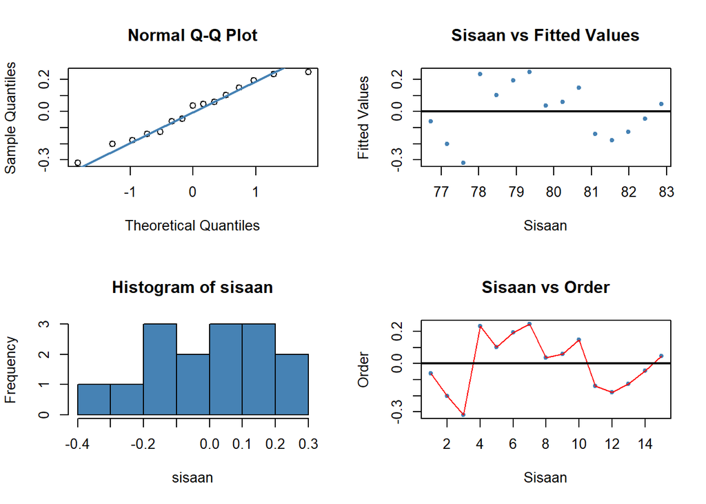

```r
#sisaan dan fitted value
sisaan<- residuals(modelipm)
fitValue<- predict(modelipm)

#Diagnostik dengan eksploratif
par(mfrow = c(2,2))
qqnorm(sisaan)
qqline(sisaan, col = "steelblue", lwd = 2)
plot(fitValue, sisaan, col = "steelblue", pch = 20, xlab = "Sisaan", ylab = "Fitted Values", main = "Sisaan vs Fitted Values")
abline(a = 0, b = 0, lwd = 2)
hist(sisaan, col = "steelblue")
plot(seq(1,15,1), sisaan, col = "steelblue", pch = 20, xlab = "Sisaan", ylab = "Order", main = "Sisaan vs Order")
lines(seq(1,15,1), sisaan, col = "red")
abline(a = 0, b = 0, lwd = 2)
```

Dua plot di samping kiri digunakan untuk melihat apakah sisaan menyebar normal. Normal Q-Q Plot di atas menunjukkan bahwa sisaan cenderung menyebar normal, tetapi histogram dari sisaan tidak menunjukkan demikian. Selanjutnya, dua plot di samping kanan digunakan untuk melihat autokorelasi. Plot Sisaan vs *Fitted Value* dan Plot Sisaan vs *Order* menunjukkan adanya pola pada sisaan. Untuk lebih lanjut akan digunakan uji formal melihat normalitas sisaan dan plot ACF dan PACF untuk melihat apakah ada autokorelasi atau tidak.

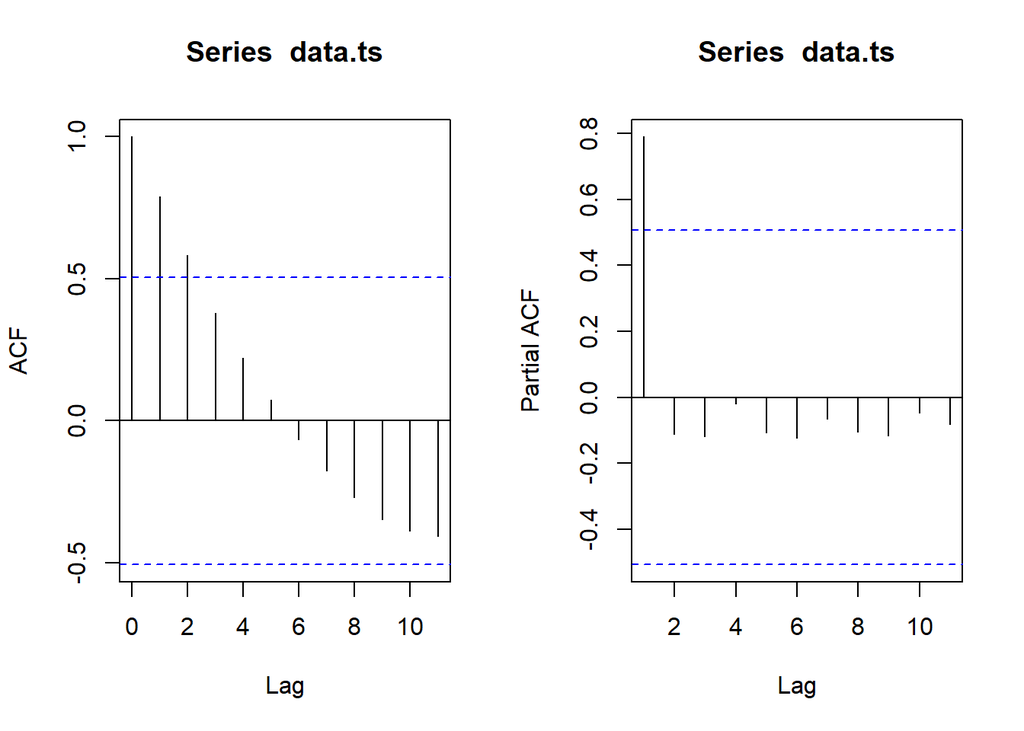

```r
par(mfrow = c(1, 2))
acf(data.ts)
pacf(data.ts)
```

```r
#Melihat Sisaan Menyebar Normal/Tidak
#H0: sisaan mengikuti sebaran normal
#H1: sisaan tidak mengikuti sebaran normal
shapiro.test(sisaan)
```

```
##
##  Shapiro-Wilk normality test
##
## data:  sisaan
## W = 0.9651, p-value = 0.7801
```

```r
ks.test(sisaan, "pnorm", mean=mean(sisaan), sd=sd(sisaan))
```

```
##
##  Exact one-sample Kolmogorov-Smirnov test
##
## data:  sisaan
## D = 0.11999, p-value = 0.9642
## alternative hypothesis: two-sided
```

Berdasarkan uji formal Saphiro-Wilk dan Kolmogorov-Smirnov didapatkan nilai *p-value* > $\alpha$ (5%). Artinya, cukup bukti untuk menyatakan sisaan berdistribusi normal.

```r
dwtest(modelipm)
```

```
##
##  Durbin-Watson test
##
## data:  modelipm
## DW = 1.2764, p-value = 0.03344
## alternative hypothesis: true autocorrelation is greater than 0
```

Menunjukkan adanya autokorelasi positif, karena nilai DW kurang dari 2. diperlukan penangan autokorelasi. Penanganan yang akan digunakan menggunakan dua metode, yaitu Cochrane-Orcutt dan Hildret-Lu.

# Penanganan Autokorelasi

## Metode Cochrane-Orcutt

Penanganan metode Cochrane-Orcutt dapat dilakukan dengan bantuan packages Orcutt pada aplikasi `R` maupun secara manual. Berikut ini ditampilkan cara menggunakan bantuan `library` *packages* `Orcutt`.

```r
#Penanganan Autokorelasi Cochrane-Orcutt
modelCO<-cochrane.orcutt(modelipm)
modelCO
```

```
## Cochrane-orcutt estimation for first order autocorrelation
##
## Call:
## lm(formula = IPM ~ Tahun, data = data)
##
##  number of interaction: 4
##  rho 0.355807
##
## Durbin-Watson statistic
## (original):    1.27635 , p-value: 3.344e-02
## (transformed): 1.90795 , p-value: 3.06e-01
##
##  coefficients:
## (Intercept)       Tahun
## -800.508014    0.436446
```

Hasil keluaran model setelah dilakukan penanganan adalah sebagai berikut.
$$y_i=-800.508014+0.436446x_t$$
. Nilai p-value 0.306 menunjukkan bahwa sudah tidak terdapat autokorelasi setelah Penanganan Cochrane-Orcutt

```r
#Rho optimum
rho<- modelCO$rho
rho
```

```
## [1] 0.3558071
```

```r
#Transformasi Manual
ipm.trans<- data$IPM[-1]-data$IPM[-12]*rho
tahun.trans<- data$Tahun[-1]-data$Tahun[-12]*rho
modelCOmanual<- lm(ipm.trans~tahun.trans)
summary(modelCOmanual)
```

```
##
## Call:
## lm(formula = ipm.trans ~ tahun.trans)
##
## Residuals:
##      Min       1Q   Median       3Q      Max
## -0.26667 -0.10317 -0.00097  0.11398  0.33038
##
## Coefficients:
##               Estimate Std. Error t value Pr(>|t|)
## (Intercept) -511.52036   23.77166  -21.52 5.93e-11 ***
## tahun.trans    0.43324    0.01829   23.69 1.91e-11 ***
## ---
## Signif. codes:  0 '***' 0.001 '**' 0.01 '*' 0.05 '.' 0.1 ' ' 1
##
## Residual standard error: 0.1707 on 12 degrees of freedom
## Multiple R-squared:  0.9791, Adjusted R-squared:  0.9773
## F-statistic: 561.3 on 1 and 12 DF,  p-value: 1.915e-11
```

## Metode Hildreth-Lu

Penanganan kedua adalah menggunakan metode Hildreth-Lu. Metode ini akan mencari nilai SSE terkecil dan dapat dicari secara manual maupun menggunakan packages. Jika menggunakan packages, gunakan `library` *packages* `HORM`.

```r
# Model awal
model <- lm(IPM ~ Tahun, data = data)

# Fungsi Hildreth-Lu
hildreth.lu.func <- function(r, model){
  x <- model.matrix(model)[, -1]   # variabel prediktor (Tahun)
  y <- model.response(model.frame(model))
  n <- length(y)
  t <- 2:n

  # Transformasi Hildreth-Lu
  y <- y[t] - r * y[t - 1]
  x <- x[t] - r * x[t - 1]

  return(lm(y ~ x))
}

# Pencarian rho yang meminimumkan SSE
r <- seq(0.1, 0.9, by = 0.1)
tab <- data.frame(
  rho = r,
  SSE = sapply(r, function(i){
    deviance(hildreth.lu.func(i, model))
  })
)

round(tab, 4)
```

```
##   rho    SSE
## 1 0.1 0.3774
## 2 0.2 0.3607
## 3 0.3 0.3522
## 4 0.4 0.3517
## 5 0.5 0.3593
## 6 0.6 0.3750
## 7 0.7 0.3988
## 8 0.8 0.4307
## 9 0.9 0.4706
```

Pertama-tama akan dicari di mana kira-kira $ρ$ yang menghasilkan SSE minimum. Pada hasil di atas terlihat $ρ$ minimum ketika 0.4. Namun, hasil tersebut masih kurang teliti sehingga akan dicari kembali $ρ$ yang lebih optimum dengan ketelitian yang lebih. Jika sebelumnya jarak antar $ρ$ yang dicari adalah 0.1, kali ini jarak antar $ρ$ adalah 0.001 dan dilakukan pada selang 0.2 sampai dengan 0.5.

```r
#Rho optimal di sekitar 0.4
rOpt <- seq(0.2,0.5, by= 0.001)
tabOpt <- data.frame("rho" = rOpt, "SSE" = sapply(rOpt, function(i){deviance(hildreth.lu.func(i, model))}))
head(tabOpt[order(tabOpt$SSE),])
```

```
##       rho       SSE
## 157 0.356 0.3509036
## 156 0.355 0.3509038
## 158 0.357 0.3509041
## 155 0.354 0.3509049
## 159 0.358 0.3509055
## 154 0.353 0.3509067
```

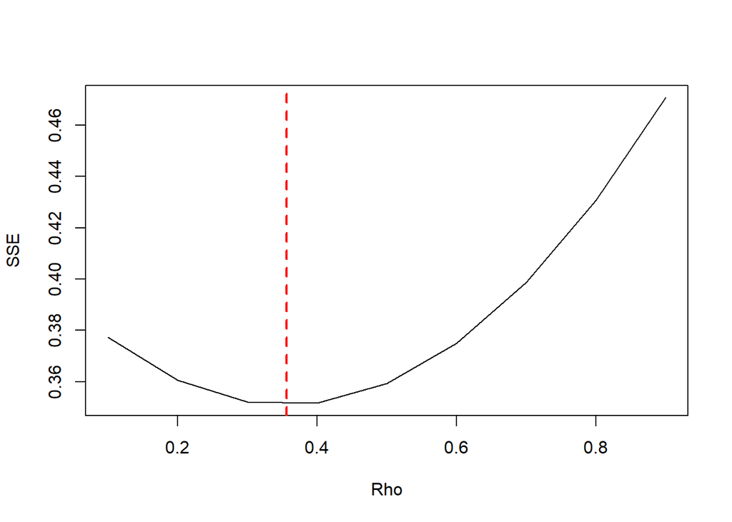

```r
#Grafik SSE optimum
par(mfrow = c(1,1))
plot(tab$SSE ~ tab$rho , type = "l", xlab = "Rho", ylab = "SSE")
abline(v = tabOpt[tabOpt$SSE==min(tabOpt$SSE),"rho"], lty = 2, col="red",lwd=2)
text(x=0.341, y=0.2397500, labels = "rho=0.341", cex = 0.8)
```

Perhitungan yang dilakukan aplikasi `R` menunjukkan bahwa nilai $ρ$ optimum, yaitu saat SSE terkecil terdapat pada 0,356. Hal tersebut juga ditunjukkan pada plot. Selanjutnya, model dapat didapatkan dengan mengevaluasi nilai $ρ$ ke dalam fungsi `hildreth.lu.func`, serta dilanjutkan dengan pengujian autokorelasi dengan uji Durbin-Watson. Namun, setelah pengecekan tersebut tidak lupa koefisien regresi tersebut digunakan untuk transformasi balik. Persamaan hasil transformasi itulah yang menjadi persamaan sesungguhnya.

```r
#Model terbaik
modelHL <- hildreth.lu.func(0.356, model)
summary(modelHL)
```

```
##
## Call:
## lm(formula = y ~ x)
##
## Residuals:
##      Min       1Q   Median       3Q      Max
## -0.26138 -0.11195  0.00628  0.11080  0.33363
##
## Coefficients:
##              Estimate Std. Error t value Pr(>|t|)
## (Intercept) -515.5268    22.8795  -22.53 3.45e-11 ***
## x              0.4365     0.0176   24.79 1.12e-11 ***
## ---
## Signif. codes:  0 '***' 0.001 '**' 0.01 '*' 0.05 '.' 0.1 ' ' 1
##
## Residual standard error: 0.171 on 12 degrees of freedom
## Multiple R-squared:  0.9808, Adjusted R-squared:  0.9793
## F-statistic: 614.6 on 1 and 12 DF,  p-value: 1.122e-11
```

```r
#Transformasi Balik
cat("y = ", coef(modelHL)[1]/(1-0.356), "+", coef(modelHL)[2],"x", sep = "")
```

```
## y = -800.5075+0.4364458x
```

Setelah dilakukan tranformasi balik, didapatkan model dengan metode Hildreth-Lu sebagai berikut.
$$y =
-800.5075+0.4364458x$$

```r
#Deteksi autokorelasi
dwtest(modelHL)
```

```
##
##  Durbin-Watson test
##
## data:  modelHL
## DW = 1.9083, p-value = 0.3062
## alternative hypothesis: true autocorrelation is greater than 0
```

# Perbandingan dan hasil

Terakhir, akan dibandingkan nilai SSE dari ketiga metode (metode awal, metode Cochrane-Orcutt, dan Hildreth-Lu).

```r
#Perbandingan
sseModelawal <- anova(modelipm)$`Sum Sq`[-1]
sseModelCO <- anova(modelCOmanual)$`Sum Sq`[-1]
sseModelHL <- anova(modelHL)$`Sum Sq`[-1]
mseModelawal <- sseModelawal/length(data$IPM)
mseModelCO <- sseModelCO/length(data$IPM)
mseModelHL <- sseModelHL/length(data$IPM)
akurasi <- matrix(c(sseModelawal,sseModelCO,sseModelHL,
                    mseModelawal,mseModelCO,mseModelHL),nrow=2,ncol=3,byrow = T)
colnames(akurasi) <- c("Model Awal", "Model Cochrane-Orcutt", "Model Hildreth-Lu")
row.names(akurasi) <- c("SSE","MSE")
akurasi
```

```
##     Model Awal Model Cochrane-Orcutt Model Hildreth-Lu
## SSE 0.40705583            0.34969393        0.35090358
## MSE 0.02713706            0.02331293        0.02339357
```

Berdasarkan hasil tersebut dapat diketahui bahwa hasil penanganan autokorelasi dengan metode Cochrane-Orcutt dan Hildreth-Lu memiliki SSE yang mirip, sebesar $0.35$ dan lebih baik dibandingkan model awal ketika autokorelasi masih terjadi, yaitu sebesar $0.40705583$. Sehingga kedua metode menunjukkan performa yang sama-sama lebih baik untuk menangani autokorelasi daripada model awal. Penggunaan kedua metode tergantung pada preferensi dari penggunanya lebih menyukai metode apa.